# UW Grade Distributions(2016 Dataset) Part #2

Author

Khadija Saho

Published

January 29, 2026

Note: This assignment is turned in late but bring submitted with a accepted extension from TA.

```r
library(dplyr)
library(stringr)
library(ggplot2)
```

## Loading Data

```r
uw_grades_original_df <- read.csv(
  "https://raw.githubusercontent.com/kylethayer/Info-201-au-24-datasets/refs/heads/main/UW-Seattle_20110-20161-Course-Grade-Data_2016-04-06.csv",
  check.names = FALSE
)
```

# Here: New Column Is Created

```r
uw_grades_df <- uw_grades_original_df |>
  mutate(
    Program_Abv = str_split_i(Course_Number, " ", 1),
    Course_Number_Num = as.integer(str_extract(Course_Number, "\\d+")),
    Term_Season = str_extract(Term, "Autumn|Spring|Summer|Winter")
  )
```

## Viewing the unique program abv

```r
uw_grades_df |>
  pull(Program_Abv) |>
  unique() |>
  sort()
```

```
  [1] "A"      "AAS"    "ACADEM" "ACCTG"  "AES"    "AFRAM"  "AIS"    "AMATH"
  [9] "ANTH"   "ARAB"   "ARCH"   "ARCHY"  "ARCTIC" "ART"    "ASIAN"  "ASL"
 [17] "ASTBIO" "ASTR"   "ATM"    "B"      "BCS"    "BIME"   "BIO"    "BIOC"
 [25] "BIOEN"  "BIOL"   "BIOST"  "BSE"    "C"      "CEE"    "CEP"    "CFR"
 [33] "CFRM"   "CHEM"   "CHID"   "CHIN"   "CHSTU"  "CL"     "CLAS"   "CM"
 [41] "COM"    "CONJ"   "CS&SS"  "CSE"    "DANCE"  "DENT"   "DENTCL" "DENTFN"
 [49] "DENTPC" "DESIGN" "DIS"    "DPHS"   "DRAMA"  "DXARTS" "E"      "ECFS"
 [57] "ECON"   "EDC&I"  "EDLPS"  "EDPSY"  "EDSPE"  "EDTEP"  "EDUC"   "EGYPT"
 [65] "EMBA"   "ENDO"   "ENGL"   "ENGR"   "ENTRE"  "ENV"    "ENVIR"  "EPI"
 [73] "ESRM"   "ESS"    "EURO"   "FHL"    "FIN"    "FINN"   "FISH"   "FRENCH"
 [81] "G"      "GEMBA"  "GEN"    "GENOME" "GEOG"   "GERMAN" "GIS"    "GREEK"
 [89] "GTTL"   "GWSS"   "HCDE"   "HCID"   "HEBR"   "HIHIM"  "HINDI"  "HIST"
 [97] "HONORS" "HSERV"  "HSMGMT" "HSTAA"  "HSTAFM" "HSTAM"  "HSTAS"  "HSTCMP"
[105] "HSTEU"  "HSTLAC" "HSTRY"  "HUM"    "I"      "IMMUN"  "IMT"    "IND"
[113] "INDO"   "INDON"  "INFO"   "INFX"   "INSC"   "INTSCI" "IPM"    "ISS"
[121] "ITAL"   "JAPAN"  "JSIS"   "KOREAN" "L"      "LAB"    "LATIN"  "LAW"
[129] "LING"   "LIS"    "LIT"    "LSJ"    "M"      "MATH"   "MCB"    "MEBI"
[137] "MEDCH"  "MEDEX"  "MGMT"   "MICROM" "MKTG"   "MODHEB" "MOLMED" "MSE"
[145] "MSIS"   "MUHST"  "MUSAP"  "MUSED"  "MUSEN"  "MUSEUM" "MUSIC"  "N"
[153] "NBIO"   "NCLIN"  "NEAR"   "NEUBEH" "NEURO"  "NME"    "NMETH"  "NORW"
[161] "NSG"    "NURS"   "NUTR"   "O"      "OCEAN"  "OPMGT"  "ORALB"  "ORALM"
[169] "ORTHO"  "P"      "PA"     "PABIO"  "PATH"   "PB"     "PCEUT"  "PEDO"
[177] "PERIO"  "PHARBE" "PHARM"  "PHARMP" "PHCOL"  "PHG"    "PHIL"   "PHRMRA"
[185] "PHYS"   "POL"    "POLSH"  "PORT"   "PPM"    "PROS"   "PRSAN"  "PSYCH"
[193] "Q"      "QERM"   "QMETH"  "R"      "REHAB"  "RELIG"  "RES"    "RHB"
[201] "RUSS"   "SCAND"  "SCTL"   "SEFS"   "SIS"    "SISA"   "SISAF"  "SISEA"
[209] "SISJE"  "SISLA"  "SISME"  "SISRE"  "SISSE"  "SLAV"   "SLAVIC" "SMA"
[217] "SMEA"   "SOC"    "SPAN"   "SPH"    "SPHSC"  "STAT"   "SWA"    "SWED"
[225] "TAGLG"  "THAI"   "TKISH"  "TMMBA"  "UCONJ"  "URBDP"  "URDU"   "VALUES"
[233] "VIET"   "WOMEN"
```

# Overall Grade Distribution Summary

```r
overall_summary <- uw_grades_df |>
  summarise(
    Courses_Count = sum(!is.na(Average_GPA)),
    Avg_of_Avg_GPA = mean(Average_GPA, na.rm = TRUE),
    Avg_Student_Count = mean(Student_Count, na.rm = TRUE),
    Min_Course_Number = min(Course_Number_Num, na.rm = TRUE),
    Max_Course_Number = max(Course_Number_Num, na.rm = TRUE)
  )
```

```r
overall_plot_df <- uw_grades_df |> filter(!is.na(Average_GPA))
```

## Histogram

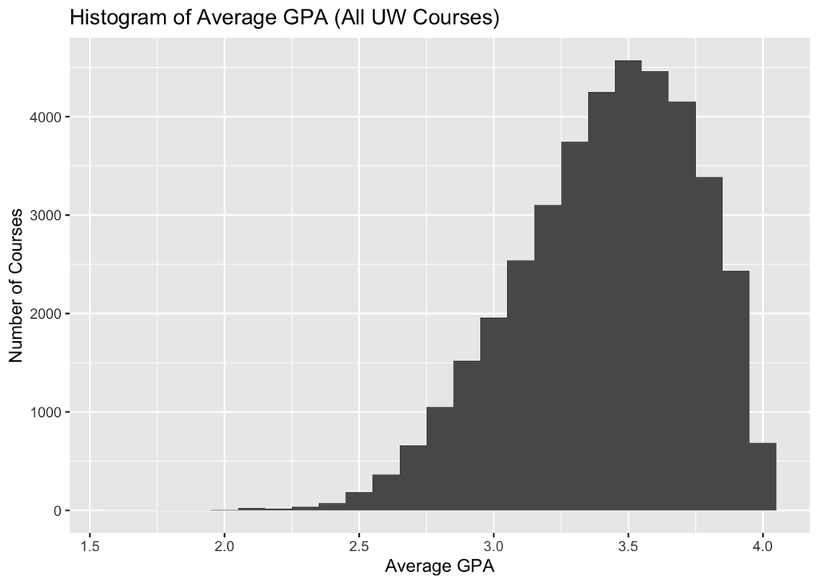

```r
ggplot(overall_plot_df, aes(x = Average_GPA)) +
  geom_histogram(binwidth = 0.1) +
  labs(
    title = "Histogram of Average GPA (All UW Courses)",
    x = "Average GPA",
    y = "Number of Courses"
  )
```

## Scatterplot

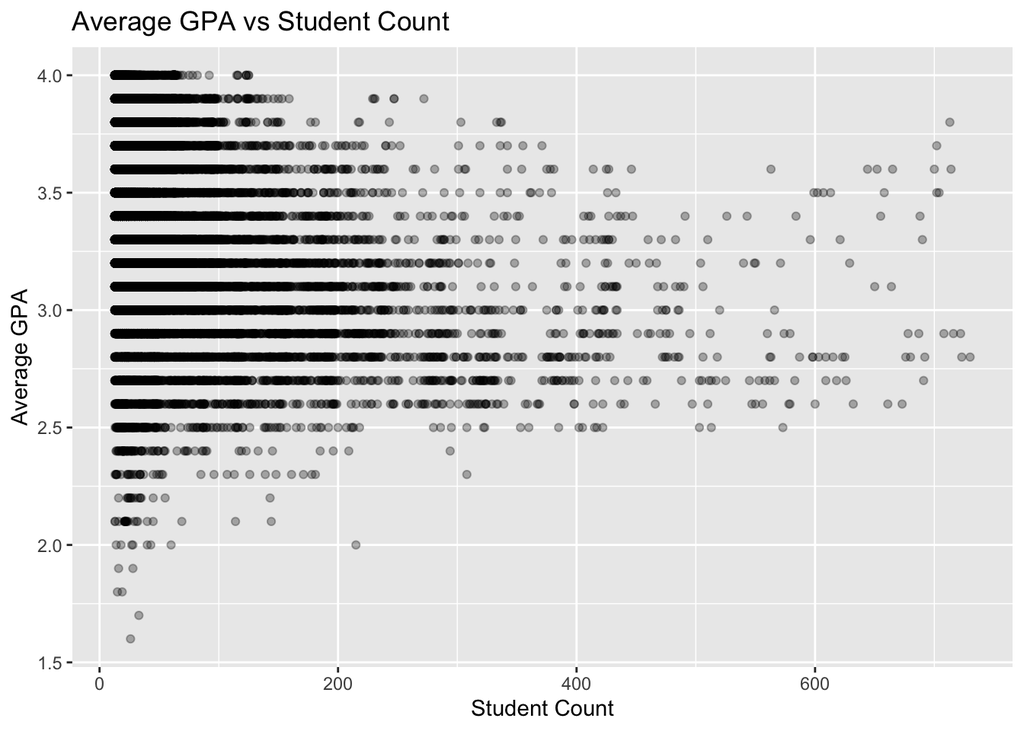

```r
ggplot(overall_plot_df, aes(x = Student_Count, y = Average_GPA)) +
  geom_point(alpha = 0.3) +
  labs(
    title = "Average GPA vs Student Count",
    x = "Student Count",
    y = "Average GPA"
  )
```

## Observation

Across the full dataset (after removing courses with missing Average_GPA), there are 39241 courses. The average of the Average_GPA is 3.41, and the average Student_Count is 45.38 students. Course numbers range from 100 to 750. From the histogram, most courses cluster around the mid-to-high 3.0 GPA range, and from looking at the scatterplot the very large classes tend to have more GPAs concentrated around the middle rather than the extreme high end.

## Filter for comparisons

```r
info_df <- uw_grades_df |> filter(Program_Abv == "INFO", !is.na(Average_GPA))
cse_df  <- uw_grades_df |> filter(Program_Abv == "CSE",  !is.na(Average_GPA))
```

```r
summarize_subset <- function(df) {
  df |>
    summarise(
      Courses_Count = sum(!is.na(Average_GPA)),
      Avg_of_Avg_GPA = mean(Average_GPA, na.rm = TRUE),
      Avg_Student_Count = mean(Student_Count, na.rm = TRUE),
      Min_Course_Number = min(Course_Number_Num, na.rm = TRUE),
      Max_Course_Number = max(Course_Number_Num, na.rm = TRUE)
    )
}

info_summary <- summarize_subset(info_df)
cse_summary  <- summarize_subset(cse_df)
```

```r
info_summary
```

```
  Courses_Count Avg_of_Avg_GPA Avg_Student_Count Min_Course_Number
1           288       3.561806          53.00694               100
  Max_Course_Number
1               498
```

```r
cse_summary
```

```
  Courses_Count Avg_of_Avg_GPA Avg_Student_Count Min_Course_Number
1           666        3.43003          77.68318               100
  Max_Course_Number
1               599
```

```r
compare1_df <- bind_rows(
  info_df |> mutate(Group = "INFO"),
  cse_df  |> mutate(Group = "CSE")
)
```

# Comparison: Histogram

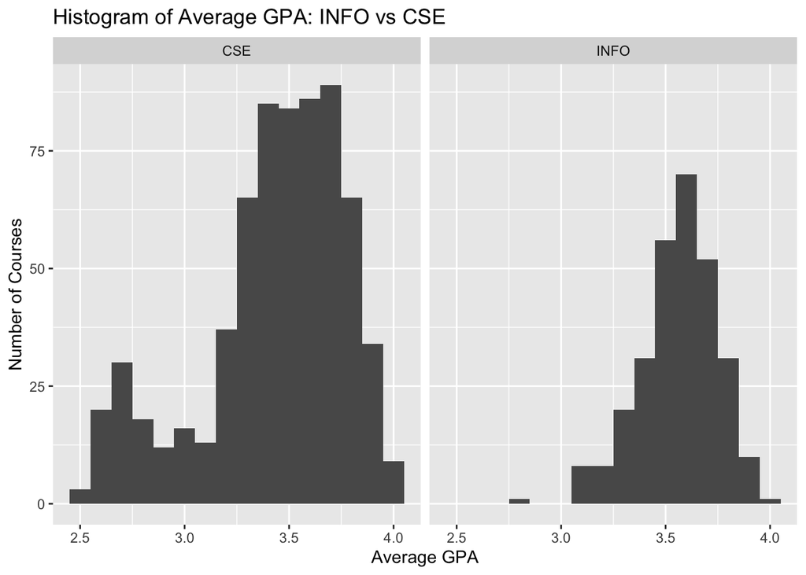

```r
ggplot(compare1_df, aes(x = Average_GPA)) +
  geom_histogram(binwidth = 0.1) +
  facet_wrap(~Group) +
  labs(
    title = "Histogram of Average GPA: INFO vs CSE",
    x = "Average GPA",
    y = "Number of Courses"
  )
```

# Comparison Scatterplot

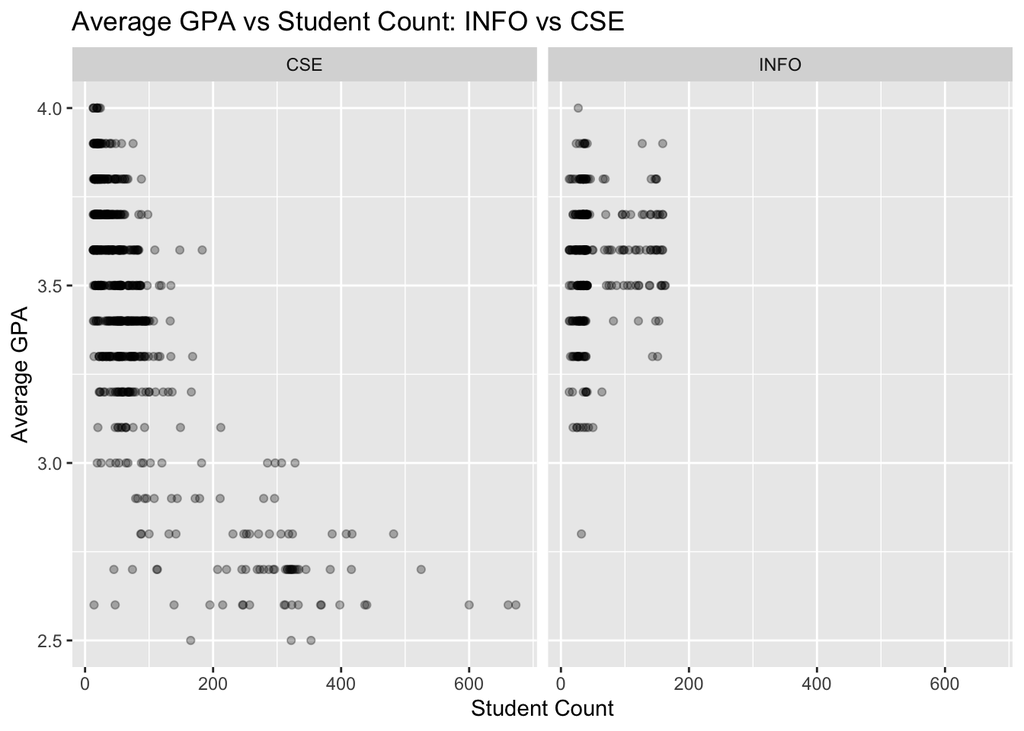

```r
ggplot(compare1_df, aes(x = Student_Count, y = Average_GPA)) +
  geom_point(alpha = 0.3) +
  facet_wrap(~Group) +
  labs(
    title = "Average GPA vs Student Count: INFO vs CSE",
    x = "Student Count",
    y = "Average GPA"
  )
```

## Summary

INFO has 288 courses with a mean GPA of 3.56, an average class size of 53.01 students, and course numbers ranging from 100 to 498. CSE has 666 courses with a mean GPA of 3.43, an average class size of 77.68 students, and course numbers ranging from 100 to 599. The histograms show that INFO courses tend to be shifted slightly toward higher GPAs compared to CSE courses. The scatterplots suggest that CSE includes more large enrollment courses and shows a wider spread of GPAs across different class sizes.

# Comparisons #2: Small vs Large Classes

### Subset summaries

```r
small_df <- uw_grades_df |> filter(Student_Count <= 30, !is.na(Average_GPA))
large_df <- uw_grades_df |> filter(Student_Count >= 200, !is.na(Average_GPA))

small_summary <- summarize_subset(small_df)
large_summary <- summarize_subset(large_df)


small_summary
```

```
  Courses_Count Avg_of_Avg_GPA Avg_Student_Count Min_Course_Number
1         21953       3.501909          20.53542               100
  Max_Course_Number
1               750
```

```r
large_summary
```

```
  Courses_Count Avg_of_Avg_GPA Avg_Student_Count Min_Course_Number
1           962       3.011538          321.1861               100
  Max_Course_Number
1               442
```

# All In One Dataframe

```r
compare2_df <- bind_rows(
  small_df |> mutate(Group = "Small (<= 30 students)"),
  large_df |> mutate(Group = "Large (>= 200 students)")
)
```

### Histogram (Small vs Large)

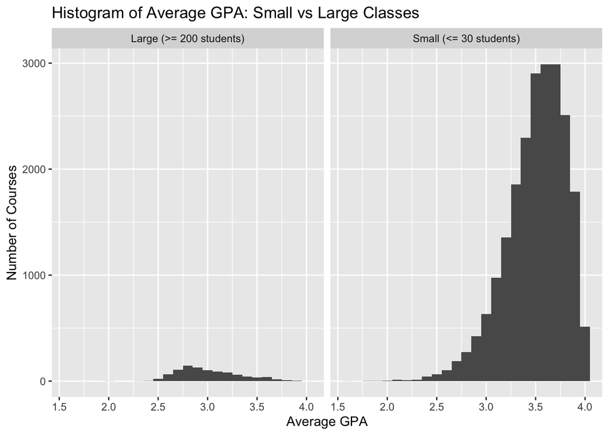

```r
ggplot(compare2_df, aes(x = Average_GPA)) +
  geom_histogram(binwidth = 0.1) +
  facet_wrap(~Group) +
  labs(
    title = "Histogram of Average GPA: Small vs Large Classes",
    x = "Average GPA",
    y = "Number of Courses"
  )
```

### Scatterplot (Small vs Large)

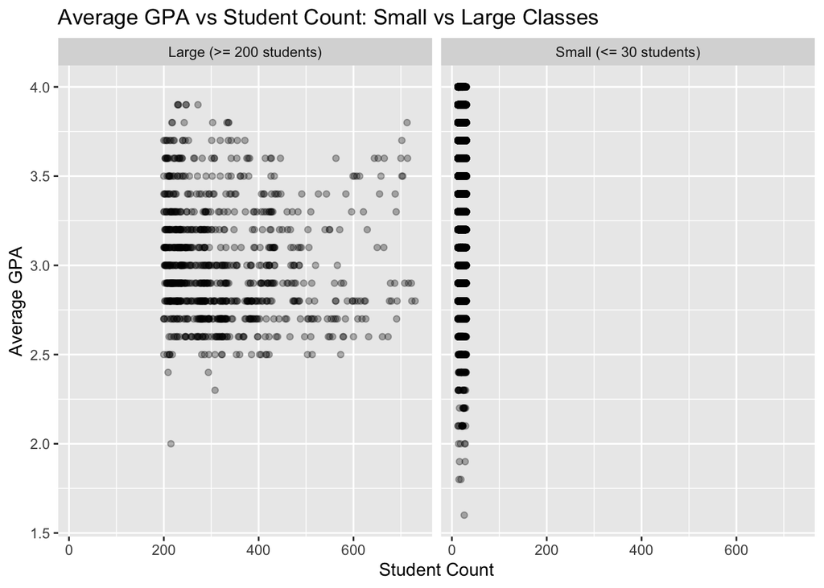

```r
ggplot(compare2_df, aes(x = Student_Count, y = Average_GPA)) +
  geom_point(alpha = 0.3) +
  facet_wrap(~Group) +
  labs(
    title = "Average GPA vs Student Count: Small vs Large Classes",
    x = "Student Count",
    y = "Average GPA"
  )
```